# Lab4 - Checkpoint 5

```r
require(tidyverse)
require(resample)
```

Neste laboratório estamos interessador em praticar **Testes de Hipótese**. Para isso iremos escolher uma pergunta já respodida no lab anterior utilizando *Intervalo de Confiança* e responder novamente utilizando teste de hipótese. Antes de tudo, vamos incrementar os dados do github adicionando o semestre associado à observação e filtrar os dados do ano de 2016.

```r
github = read_csv(file = "../data/github-users-committing-filetypes.csv")

ts = github %>% filter(file_extension == "ts")
ts_2016 = ts %>% filter(the_year == 2016)
ts_2016 = ts_2016 %>%
  mutate(semester = if_else(the_month <= 6, 1, 2))
```

## Há diferença significativa na “popularidade” da linguagem Typescript comparando os dois semestres de 2016?

Para responder essa pergunta utilizaremos a informação referente à quantidade de usuários que editaram arquivos com extensão “.ts” (users) e a coluna referente ao semestre do ano, com o objetivo de comparar os semestres de 2016 no quesito “popularidade” da linguagem typescript. O modo do teste de permutação será *Two-sided* ou *Two-tailed*. A hipótese nula que estamos estudando é:

**H0:** A média de popularidade da linguagem Typescript é igual nos dois semestres de 2016. (Não há diferença significativa entre as médias)

**H1:** A média de popularidade da linguagem Typescript é diferente nos dois semestres de 2016. (Há diferença significativa entre as médias)

```r
pt <- permutationTest2(ts_2016,
                       mean(users),
                       treatment = semester,
                       alternative = "two.sided", # two-tailed
                       R = 10000,
                       seed = 1000)
show(t(pt$stats))
```

```
##             mean(users): 1-2
## Observed    "-125.1703"
## Mean        "-0.08244947"
## Alternative "two.sided"
## PValue      "0.00019998"
```

Obtendo como resultado do teste **p-value = 0.00019998**, temos uma forte evidência para **rejeitar H0**. E podemos concluir que há diferença significativa na “popularidade” da linguagem Typescript comparando os dois semestres de 2016.

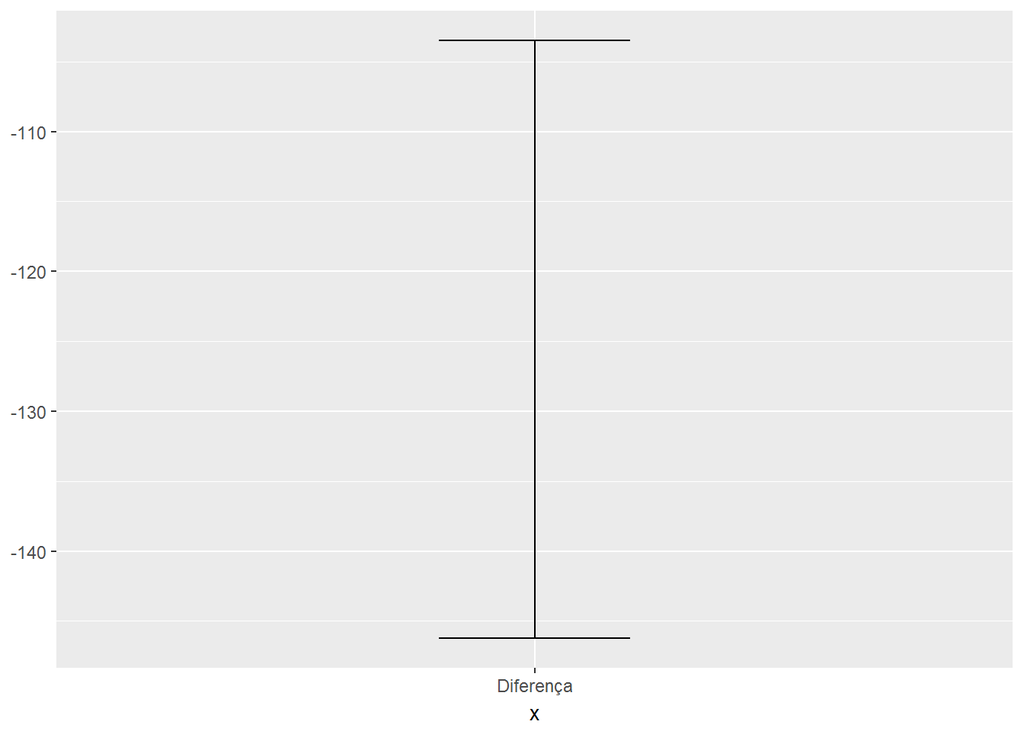

```r
# Bootstrap calculando a diferenca
b.diff.means = bootstrap2(ts_2016$users,
                          mean,
                          treatment = ts_2016$semester) # 10000 amostragens por padrão

means.diff = CI.percentile(b.diff.means, probs = c(.025, .975)) #confianca de 95%

data.frame(means.diff) %>%
  ggplot(aes(x = "Diferença", ymin = X2.5., ymax = X97.5.)) +
  geom_errorbar(width = .2)
```

```r
means.diff
```

```
##                2.5%     97.5%
## mean: 1-2 -146.2247 -103.5097
```

Comparando as duas técnicas, ICs x Teste de Hipótese, achei IC com reamostragem algo mais intuitivo e mais próximo do que é feito na realidade (no sentido das várias amostras de uma população). Além disso, acho mais fácil a interpretação de um intervalo do que um número apenas para representar toda a comparação, que é o caso do p-value. Porém é importante conhecer as duas formas, já que ainda existem muitos estudos os quais utilizam teste de hipótese.